# Earmark incidence and macro-fiscal indicators

IMF research project

2026-08-26

This notebook describes cross-country associations between functional-earmark incidence in the selected legal Census corpus and six macro-fiscal indicators. It is a descriptive exercise only: the fitted lines and correlations are not causal estimates. The legal database is de jure and does not measure revenue collection or expenditure execution.

# 1. Load and validate the sources

All inputs are read without modification. The incidence file is explicitly read as semicolon-delimited because that is its saved format; the corpus coverage file is comma-delimited.

```r
missing_inputs <- names(input_paths)[!file.exists(input_paths)]
if (length(missing_inputs) > 0L) {
  stop(
    "Missing required input files: ",
    paste(missing_inputs, collapse = "; ")
  )
}

input_md5_before <- unname(tools::md5sum(input_paths))

incidence_header <- read_lines(
  input_paths[["incidence"]], n_max = 1L, progress = FALSE
)
if (!str_detect(incidence_header, fixed(";"))) {
  stop("02_country_summary.csv is not semicolon-delimited as expected.")
}

incidence_raw <- read_delim(
  input_paths[["incidence"]],
  delim = ";",
  col_types = cols(.default = col_character()),
  trim_ws = TRUE,
  show_col_types = FALSE,
  progress = FALSE
)

coverage_raw <- read_csv(
  input_paths[["corpus_coverage"]],
  col_types = cols(.default = col_character()),
  show_col_types = FALSE,
  progress = FALSE
)

imf_raw <- read_excel(
  input_paths[["imf_world"]],
  sheet = "Data",
  na = c("", "NA")
)

required_fields <- list(
  incidence = c("country", "allocation_incidence_E_D"),
  corpus_coverage = c(
    "dataset", "country", "n_documents", "document_years", "corpus_type"
  ),
  imf_world = c("ISO3", "year", indicator_meta$macro_indicator)
)

source_objects <- list(
  incidence = incidence_raw,
  corpus_coverage = coverage_raw,
  imf_world = imf_raw
)

input_inventory <- imap_dfr(source_objects, function(data, source) {
  missing_fields <- setdiff(required_fields[[source]], names(data))
  tibble(
    source = source,
    file = basename(input_paths[[source]]),
    rows = nrow(data),
    columns = ncol(data),
    missing_required_fields = if (length(missing_fields) == 0L) {
      NA_character_
    } else {
      paste(missing_fields, collapse = "; ")
    },
    schema_status = if_else(
      length(missing_fields) == 0L, "valid", "invalid"
    )
  )
})

if (any(input_inventory$schema_status == "invalid")) {
  print(input_inventory)
  stop("At least one input is missing required columns.")
}
```

```r
display_table(input_inventory)
```

| source | file | rows | columns | missing_required_fields | schema_status |
| --- | --- | --- | --- | --- | --- |
| incidence | 02_country_summary.csv | 19 | 15 | NA | valid |
| corpus_coverage | 01_country_corpus_coverage.csv | 38 | 5 | NA | valid |
| imf_world | world_imf_2026.xlsx | 8775 | 40 | NA | valid |

# 2. Define the Francophone sample and legal-snapshot year

The requested sample rule is implemented exactly: every country in the saved partial/exclusive country summary is retained except Ghana, Nigeria, and South Africa. No additional language or regional filter is applied.

```r
incidence <- incidence_raw %>%
  transmute(
    country = str_trim(country),
    allocation_incidence_E_D = strict_numeric(
      allocation_incidence_E_D,
      "allocation_incidence_E_D",
      "02_country_summary.csv"
    )
  )

incidence_key_problems <- incidence %>%
  filter(is_blank(country)) %>%
  bind_rows(
    incidence %>%
      filter(!is_blank(country)) %>%
      count(country, name = "n_rows") %>%
      filter(n_rows != 1L) %>%
      mutate(allocation_incidence_E_D = NA_real_)
  )

incidence_value_problems <- incidence %>%
  filter(
    is.na(allocation_incidence_E_D) |
      allocation_incidence_E_D < 0 |
      allocation_incidence_E_D > 1
  )

if (nrow(incidence_key_problems) > 0L ||
    nrow(incidence_value_problems) > 0L) {
  print(incidence_key_problems)
  print(incidence_value_problems)
  stop("Country keys or incidence values are invalid.")
}

excluded_sample_rows <- incidence %>%
  filter(country %in% excluded_countries) %>%
  arrange(country)

francophone_incidence <- incidence %>%
  filter(!country %in% excluded_countries) %>%
  arrange(country)

sample_audit <- tibble(
  measure = c(
    "Countries in source summary",
    "Countries excluded by instruction",
    "Countries retained"
  ),
  n_countries = c(
    n_distinct(incidence$country),
    n_distinct(excluded_sample_rows$country),
    n_distinct(francophone_incidence$country)
  ),
  countries = c(
    paste(sort(unique(incidence$country)), collapse = "; "),
    paste(sort(unique(excluded_sample_rows$country)), collapse = "; "),
    paste(sort(unique(francophone_incidence$country)), collapse = "; ")
  )
)
```

```r
coverage_census <- coverage_raw %>%
  filter(dataset == "Census") %>%
  mutate(
    country = str_trim(country),
    year_tokens = str_extract_all(
      document_years,
      "(?<![0-9])[0-9]{4}(?![0-9])"
    ),
    n_year_tokens = lengths(year_tokens),
    CGI_year = map_int(
      year_tokens,
      ~if (length(.x) == 1L) as.integer(.x) else NA_integer_
    )
  ) %>%
  select(
    country, n_documents, document_years, corpus_type,
    n_year_tokens, CGI_year
  )

coverage_key_problems <- coverage_census %>%
  filter(!is_blank(country)) %>%
  count(country, name = "n_rows") %>%
  filter(n_rows != 1L)

unmatched_incidence_to_coverage <- francophone_incidence %>%
  anti_join(coverage_census, by = "country")
unmatched_coverage_to_incidence <- coverage_census %>%
  filter(!country %in% excluded_countries) %>%
  anti_join(francophone_incidence, by = "country")

year_audit <- francophone_incidence %>%
  left_join(coverage_census, by = "country") %>%
  arrange(country)

missing_or_ambiguous_cgi_years <- year_audit %>%
  filter(is.na(CGI_year) | n_year_tokens != 1L)

if (nrow(coverage_key_problems) > 0L ||
    nrow(unmatched_incidence_to_coverage) > 0L ||
    nrow(missing_or_ambiguous_cgi_years) > 0L) {
  print(coverage_key_problems)
  print(unmatched_incidence_to_coverage)
  print(missing_or_ambiguous_cgi_years)
  stop(
    "A unique saved Census/CGI legal-snapshot year could not be established ",
    "for every retained country. No year was inferred."
  )
}

country_analysis_base <- year_audit %>%
  select(country, CGI_year, allocation_incidence_E_D) %>%
  arrange(country)
```

```r
display_table(sample_audit)
```

| measure | n_countries | countries |
| --- | --- | --- |
| Countries in source summary | 19 | BEN; BFA; CAF; CIV; CMR; COD; COG; COM; GAB; GHA; GIN; MDG; MLI; NER; NGA; SEN; TCD; TGO; ZAF |
| Countries excluded by instruction | 3 | GHA; NGA; ZAF |
| Countries retained | 16 | BEN; BFA; CAF; CIV; CMR; COD; COG; COM; GAB; GIN; MDG; MLI; NER; SEN; TCD; TGO |

```r
display_table(
  year_audit %>%
    select(
      country, allocation_incidence_E_D, n_documents,
      document_years, corpus_type, CGI_year
    )
)
```

| country | allocation_incidence_E_D | n_documents | document_years | corpus_type | CGI_year |
| --- | --- | --- | --- | --- | --- |
| BEN | 0.0741 | 1 | 2025 | single_document | 2025 |
| BFA | 0.1333 | 1 | 2024 | single_document | 2024 |
| CAF | 0.2660 | 1 | 2023 | single_document | 2023 |
| CIV | 0.3230 | 1 | 2026 | single_document | 2026 |
| CMR | 0.1867 | 1 | 2025 | single_document | 2025 |
| COD | 0.0000 | 1 | 2021 | single_document | 2021 |
| COG | 0.1092 | 1 | 2025 | single_document | 2025 |
| COM | 0.0400 | 1 | 2023 | single_document | 2023 |
| GAB | 0.0357 | 1 | 2022 | single_document | 2022 |
| GIN | 0.0769 | 1 | 2021 | single_document | 2021 |
| MDG | 0.0930 | 1 | 2026 | single_document | 2026 |
| MLI | 0.0400 | 1 | 2026 | single_document | 2026 |
| NER | 0.0950 | 1 | 2025 | single_document | 2025 |
| SEN | 0.0000 | 1 | 2025 | single_document | 2025 |
| TCD | 0.0991 | 1 | 2024 | single_document | 2024 |
| TGO | 0.0294 | 1 | 2025 | single_document | 2025 |

```r
cat(
  "Unmatched retained countries in corpus coverage: ",
  nrow(unmatched_incidence_to_coverage), ".\n",
  "Non-excluded Census countries absent from the incidence summary: ",
  nrow(unmatched_coverage_to_incidence), ".\n",
  "Missing or ambiguous CGI years: ",
  nrow(missing_or_ambiguous_cgi_years), ".\n",
  sep = ""
)
```

```
## Unmatched retained countries in corpus coverage: 0.
## Non-excluded Census countries absent from the incidence summary: 0.
## Missing or ambiguous CGI years: 0.
```

# 3. Prepare the IMF series and construct the three-year windows

For country `i`, each requested macro average uses available non-missing values in `CGI_year`, `CGI_year + 1`, and `CGI_year + 2`. Missing years and values are left missing; they are not replaced by earlier or later observations.

```r
imf_data <- imf_raw %>%
  transmute(
    country = str_trim(as.character(ISO3)),
    year = strict_numeric(year, "year", "world_imf_2026.xlsx"),
    across(
      all_of(indicator_meta$macro_indicator),
      ~strict_numeric(.x, cur_column(), "world_imf_2026.xlsx")
    )
  )

non_integer_years <- imf_data %>%
  filter(!is.na(year), year != floor(year))
if (nrow(non_integer_years) > 0L) {
  print(non_integer_years)
  stop("The IMF year field contains non-integer values.")
}
imf_data <- imf_data %>% mutate(year = as.integer(year))

imf_key_problems <- imf_data %>%
  filter(!is_blank(country), !is.na(year)) %>%
  count(country, year, name = "n_rows") %>%
  filter(n_rows != 1L)

unmatched_incidence_to_imf <- country_analysis_base %>%
  anti_join(imf_data %>% distinct(country), by = "country")

if (nrow(imf_key_problems) > 0L) {
  print(imf_key_problems)
  stop("The IMF data contain duplicate country-year rows.")
}

imf_year_coverage <- imf_data %>%
  summarise(
    first_year = min(year, na.rm = TRUE),
    last_year = max(year, na.rm = TRUE),
    n_country_year_rows = n()
  )
```

```r
macro_window_grid <- country_analysis_base %>%
  crossing(year_offset = 0:2) %>%
  mutate(year = CGI_year + year_offset)

imf_long <- imf_data %>%
  select(country, year, all_of(indicator_meta$macro_indicator)) %>%
  pivot_longer(
    cols = all_of(indicator_meta$macro_indicator),
    names_to = "macro_indicator",
    values_to = "macro_value"
  )

macro_window_observations <- macro_window_grid %>%
  select(country, CGI_year, allocation_incidence_E_D, year) %>%
  crossing(macro_indicator = indicator_meta$macro_indicator) %>%
  left_join(
    imf_long,
    by = c("country", "year", "macro_indicator")
  ) %>%
  left_join(
    indicator_meta %>%
      select(macro_indicator, indicator, indicator_label, indicator_order),
    by = "macro_indicator"
  ) %>%
  arrange(country, indicator_order, year)

macro_averages <- macro_window_observations %>%
  group_by(
    country, CGI_year, allocation_incidence_E_D,
    macro_indicator, indicator, indicator_label, indicator_order
  ) %>%
  summarise(
    start_year = first(CGI_year),
    end_year = first(CGI_year) + 2L,
    n_years_used = sum(!is.na(macro_value)),
    macro_3yr_average = if (n_years_used == 0L) {
      NA_real_
    } else {
      mean(macro_value, na.rm = TRUE)
    },
    .groups = "drop"
  ) %>%
  mutate(fewer_than_3_years = n_years_used < 3L) %>%
  arrange(country, indicator_order) %>%
  select(
    country,
    CGI_year,
    start_year,
    end_year,
    allocation_incidence_E_D,
    macro_indicator,
    indicator,
    indicator_label,
    macro_3yr_average,
    n_years_used,
    fewer_than_3_years
  )

average_validation <- macro_averages %>%
  mutate(
    valid_start = start_year == CGI_year,
    valid_end = end_year == CGI_year + 2L,
    valid_n = n_years_used >= 0L & n_years_used <= 3L,
    valid_missing_rule = is.na(macro_3yr_average) == (n_years_used == 0L),
    valid_flag = fewer_than_3_years == (n_years_used < 3L)
  ) %>%
  filter(!(valid_start & valid_end & valid_n & valid_missing_rule & valid_flag))

if (nrow(average_validation) > 0L) {
  print(average_validation)
  stop("At least one three-year average failed its construction checks.")
}

missing_macro_observations <- macro_window_observations %>%
  filter(is.na(macro_value)) %>%
  group_by(country, macro_indicator, indicator_label) %>%
  summarise(
    missing_years = paste(year, collapse = "; "),
    n_missing_years = n(),
    .groups = "drop"
  ) %>%
  mutate(indicator_order = match(
    macro_indicator, indicator_meta$macro_indicator
  )) %>%
  arrange(country, indicator_order) %>%
  select(-indicator_order)

short_window_audit <- macro_averages %>%
  filter(fewer_than_3_years) %>%
  arrange(country, match(macro_indicator, indicator_meta$macro_indicator)) %>%
  select(
    country, macro_indicator, indicator_label,
    start_year, end_year, n_years_used,
    macro_3yr_average, fewer_than_3_years
  )
```

```r
display_table(imf_year_coverage)
```

| first_year | last_year | n_country_year_rows |
| --- | --- | --- |
| 1980 | 2024 | 8775 |

```r
cat(
  "Countries in the incidence sample without any IMF country rows: ",
  nrow(unmatched_incidence_to_imf), ".\n",
  "Duplicate IMF country-year keys: ", nrow(imf_key_problems), ".\n",
  sep = ""
)
```

```
## Countries in the incidence sample without any IMF country rows: 0.
## Duplicate IMF country-year keys: 0.
```

```r
display_table(missing_macro_observations)
```

| country | macro_indicator | indicator_label | missing_years | n_missing_years |
| --- | --- | --- | --- | --- |
| BEN | TaxInc | Income and profit taxes | 2025; 2026; 2027 | 3 |
| BEN | TaxSal | Sales and production taxes | 2025; 2026; 2027 | 3 |
| BEN | TaxPro | Property taxes | 2025; 2026; 2027 | 3 |
| BEN | Grants | Grants | 2025; 2026; 2027 | 3 |
| BEN | TaxRev | Tax revenue | 2025; 2026; 2027 | 3 |
| BEN | TaxTra | Taxes on international trade | 2025; 2026; 2027 | 3 |
| BFA | TaxInc | Income and profit taxes | 2025; 2026 | 2 |
| BFA | TaxSal | Sales and production taxes | 2025; 2026 | 2 |
| BFA | TaxPro | Property taxes | 2025; 2026 | 2 |
| BFA | Grants | Grants | 2025; 2026 | 2 |
| BFA | TaxRev | Tax revenue | 2025; 2026 | 2 |
| BFA | TaxTra | Taxes on international trade | 2025; 2026 | 2 |
| CAF | TaxInc | Income and profit taxes | 2025 | 1 |
| CAF | TaxSal | Sales and production taxes | 2025 | 1 |
| CAF | TaxPro | Property taxes | 2023; 2024; 2025 | 3 |
| CAF | Grants | Grants | 2025 | 1 |
| CAF | TaxRev | Tax revenue | 2025 | 1 |
| CAF | TaxTra | Taxes on international trade | 2025 | 1 |
| CIV | TaxInc | Income and profit taxes | 2026; 2027; 2028 | 3 |
| CIV | TaxSal | Sales and production taxes | 2026; 2027; 2028 | 3 |
| CIV | TaxPro | Property taxes | 2026; 2027; 2028 | 3 |
| CIV | Grants | Grants | 2026; 2027; 2028 | 3 |
| CIV | TaxRev | Tax revenue | 2026; 2027; 2028 | 3 |
| CIV | TaxTra | Taxes on international trade | 2026; 2027; 2028 | 3 |
| CMR | TaxInc | Income and profit taxes | 2025; 2026; 2027 | 3 |
| CMR | TaxSal | Sales and production taxes | 2025; 2026; 2027 | 3 |
| CMR | TaxPro | Property taxes | 2025; 2026; 2027 | 3 |
| CMR | Grants | Grants | 2025; 2026; 2027 | 3 |
| CMR | TaxRev | Tax revenue | 2025; 2026; 2027 | 3 |
| CMR | TaxTra | Taxes on international trade | 2025; 2026; 2027 | 3 |

[output cut: 51 more lines]

```r
display_table(short_window_audit)
```

| country | macro_indicator | indicator_label | start_year | end_year | n_years_used | macro_3yr_average | fewer_than_3_years |
| --- | --- | --- | --- | --- | --- | --- | --- |
| BEN | TaxInc | Income and profit taxes | 2025 | 2027 | 0 | NA | TRUE |
| BEN | TaxSal | Sales and production taxes | 2025 | 2027 | 0 | NA | TRUE |
| BEN | TaxPro | Property taxes | 2025 | 2027 | 0 | NA | TRUE |
| BEN | Grants | Grants | 2025 | 2027 | 0 | NA | TRUE |
| BEN | TaxRev | Tax revenue | 2025 | 2027 | 0 | NA | TRUE |
| BEN | TaxTra | Taxes on international trade | 2025 | 2027 | 0 | NA | TRUE |
| BFA | TaxInc | Income and profit taxes | 2024 | 2026 | 1 | 6.8876 | TRUE |
| BFA | TaxSal | Sales and production taxes | 2024 | 2026 | 1 | 8.7596 | TRUE |
| BFA | TaxPro | Property taxes | 2024 | 2026 | 1 | 0.6187 | TRUE |
| BFA | Grants | Grants | 2024 | 2026 | 1 | 1.2729 | TRUE |
| BFA | TaxRev | Tax revenue | 2024 | 2026 | 1 | 18.8043 | TRUE |
| BFA | TaxTra | Taxes on international trade | 2024 | 2026 | 1 | 2.5229 | TRUE |
| CAF | TaxInc | Income and profit taxes | 2023 | 2025 | 2 | 2.0124 | TRUE |
| CAF | TaxSal | Sales and production taxes | 2023 | 2025 | 2 | 3.4109 | TRUE |
| CAF | TaxPro | Property taxes | 2023 | 2025 | 0 | NA | TRUE |
| CAF | Grants | Grants | 2023 | 2025 | 2 | 5.6021 | TRUE |
| CAF | TaxRev | Tax revenue | 2023 | 2025 | 2 | 7.4440 | TRUE |
| CAF | TaxTra | Taxes on international trade | 2023 | 2025 | 2 | 2.0208 | TRUE |
| CIV | TaxInc | Income and profit taxes | 2026 | 2028 | 0 | NA | TRUE |
| CIV | TaxSal | Sales and production taxes | 2026 | 2028 | 0 | NA | TRUE |
| CIV | TaxPro | Property taxes | 2026 | 2028 | 0 | NA | TRUE |
| CIV | Grants | Grants | 2026 | 2028 | 0 | NA | TRUE |
| CIV | TaxRev | Tax revenue | 2026 | 2028 | 0 | NA | TRUE |
| CIV | TaxTra | Taxes on international trade | 2026 | 2028 | 0 | NA | TRUE |
| CMR | TaxInc | Income and profit taxes | 2025 | 2027 | 0 | NA | TRUE |
| CMR | TaxSal | Sales and production taxes | 2025 | 2027 | 0 | NA | TRUE |
| CMR | TaxPro | Property taxes | 2025 | 2027 | 0 | NA | TRUE |
| CMR | Grants | Grants | 2025 | 2027 | 0 | NA | TRUE |
| CMR | TaxRev | Tax revenue | 2025 | 2027 | 0 | NA | TRUE |
| CMR | TaxTra | Taxes on international trade | 2025 | 2027 | 0 | NA | TRUE |

[output cut: 51 more lines]

# 4. Complete-case plot samples and correlations

Each correlation uses exactly the complete country observations displayed in the corresponding scatter plot.

```r
plot_data_by_indicator <- set_names(
  map(indicator_meta$macro_indicator, function(indicator_code) {
    macro_averages %>%
      filter(
        macro_indicator == indicator_code,
        !is.na(macro_3yr_average),
        !is.na(allocation_incidence_E_D)
      ) %>%
      arrange(country) %>%
      select(
        country,
        CGI_year,
        start_year,
        end_year,
        allocation_incidence_E_D,
        macro_indicator,
        indicator,
        indicator_label,
        macro_3yr_average,
        n_years_used,
        fewer_than_3_years
      )
  }),
  indicator_meta$macro_indicator
)

calculate_correlations <- function(data, indicator_code) {
  n_countries <- nrow(data)
  enough_variation <- n_countries >= 2L &&
    length(unique(data$macro_3yr_average)) > 1L &&
    length(unique(data$allocation_incidence_E_D)) > 1L
  tibble(
    macro_indicator = indicator_code,
    n_countries = n_countries,
    pearson_r = if (enough_variation) {
      cor(
        data$macro_3yr_average,
        data$allocation_incidence_E_D,
        method = "pearson"
      )
    } else {
      NA_real_
    },
    spearman_rho = if (enough_variation) {
      cor(
        data$macro_3yr_average,
        data$allocation_incidence_E_D,
        method = "spearman"
      )
    } else {
      NA_real_
    }
  )
}

correlation_summary <- imap_dfr(
  plot_data_by_indicator,
  ~calculate_correlations(.x, .y)
) %>%
  left_join(
    indicator_meta %>%
      select(macro_indicator, indicator, indicator_label, indicator_order),
    by = "macro_indicator"
  ) %>%
  arrange(indicator_order) %>%
  select(
    indicator,
    macro_indicator,
    indicator_label,
    n_countries,
    pearson_r,
    spearman_rho
  )

correlation_reconciliation <- imap_dfr(
  plot_data_by_indicator,
  function(data, indicator_code) {
    tibble(
      macro_indicator = indicator_code,
      plot_rows = nrow(data),
      distinct_countries = n_distinct(data$country),
      correlation_n = correlation_summary %>%
        filter(macro_indicator == indicator_code) %>%
        pull(n_countries),
      duplicate_countries = sum(duplicated(data$country))
    )
  }
) %>%
  mutate(
    passed = plot_rows == distinct_countries &
      plot_rows == correlation_n &
      duplicate_countries == 0L
  )

if (!all(correlation_reconciliation$passed)) {
  print(correlation_reconciliation %>% filter(!passed))
  stop("Plot samples and correlation samples do not reconcile.")
}
```

```r
display_table(correlation_summary)
```

| indicator | macro_indicator | indicator_label | n_countries | pearson_r | spearman_rho |
| --- | --- | --- | --- | --- | --- |
| income_profit_taxes | TaxInc | Income and profit taxes | 7 | -0.2568 | -0.1429 |
| sales_production_taxes | TaxSal | Sales and production taxes | 7 | 0.0809 | 0.3214 |
| property_taxes | TaxPro | Property taxes | 3 | 0.2659 | 0.5000 |
| grants | Grants | Grants | 7 | 0.3992 | 0.1786 |
| tax_revenue | TaxRev | Tax revenue | 7 | -0.0997 | -0.2143 |
| international_trade_taxes | TaxTra | Taxes on international trade | 7 | 0.2034 | 0.2857 |

```r
display_table(correlation_reconciliation)
```

| macro_indicator | plot_rows | distinct_countries | correlation_n | duplicate_countries | passed |
| --- | --- | --- | --- | --- | --- |
| TaxInc | 7 | 7 | 7 | 0 | TRUE |
| TaxSal | 7 | 7 | 7 | 0 | TRUE |
| TaxPro | 3 | 3 | 3 | 0 | TRUE |
| Grants | 7 | 7 | 7 | 0 | TRUE |
| TaxRev | 7 | 7 | 7 | 0 | TRUE |
| TaxTra | 7 | 7 | 7 | 0 | TRUE |

# 5. Scatter plots

```r
make_scatter_plot <- function(plot_data, indicator_code) {
  meta <- indicator_meta %>%
    filter(macro_indicator == indicator_code)
  correlation_row <- correlation_summary %>%
    filter(macro_indicator == indicator_code)

  pearson_text <- if (is.na(correlation_row$pearson_r)) {
    "NA"
  } else {
    sprintf("%.2f", correlation_row$pearson_r)
  }

  has_fit <- nrow(plot_data) >= 2L &&
    length(unique(plot_data$macro_3yr_average)) > 1L &&
    length(unique(plot_data$allocation_incidence_E_D)) > 1L

  plot_object <- ggplot(
    plot_data,
    aes(
      x = macro_3yr_average,
      y = allocation_incidence_E_D
    )
  )

  if (has_fit) {
    plot_object <- plot_object +
      geom_smooth(
        method = "lm",
        formula = y ~ x,
        se = TRUE,
        colour = "#17365D",
        fill = "#C8D4DE",
        alpha = 0.22,
        linewidth = 0.95
      )
  }

  plot_object +
    geom_point(
      shape = 21,
      size = 4.8,
      stroke = 0.9,
      fill = "#1F4E79",
      colour = "#FFFFFF"
    ) +
    geom_text_repel(
      aes(label = country),
      seed = 20260826,
      size = 5.0,
      colour = "#2F3A44",
      fontface = "bold",
      box.padding = 0.45,
      point.padding = 0.35,
      min.segment.length = 0,
      segment.colour = "#8A969F",
      segment.size = 0.35,
      max.overlaps = Inf
    ) +
    scale_x_continuous(
      labels = label_number(accuracy = 0.1, suffix = "%"),
      expand = expansion(mult = c(0.08, 0.18))
    ) +
    scale_y_continuous(
      breaks = seq(0, 0.30, by = 0.10),
      labels = label_percent(accuracy = 1),
      expand = expansion(mult = c(0.02, 0.18))
    ) +
    coord_cartesian(ylim = c(0, 0.35)) +
    labs(
      title = meta$plot_title,
      subtitle = paste0(
        "Cross-country association \u00b7 Pearson r = ", pearson_text
      ),
      x = meta$x_axis_label,
      y = paste0(
        "Share of identified Census instruments\n",
        "linked to functional earmarks"
      ),
      caption = str_wrap(
        paste0(
          "Note: Descriptive cross-country association only; the fitted ",
          "line is not causal. Earmark incidence is measured relative to ",
          "the selected legal Census corpus. Macro averages use available ",
          "non-missing observations over the three-year window beginning in the CGI year."
        ),
        width = 125
      )
    ) +
    theme_minimal(base_size = 15) +
    theme(
      plot.title.position = "plot",
      plot.title = element_text(
        face = "bold", colour = "#222222", size = 19
      ),
      plot.subtitle = element_text(
        colour = "#4D4D4D", size = 14,
        margin = margin(b = 12)
      ),
      plot.caption = element_text(
        colour = "#666666", hjust = 0, size = 10.5,
        margin = margin(t = 12)
      ),
      axis.title = element_text(
        face = "bold", colour = "#333333", size = 14.5
      ),
      axis.text = element_text(colour = "#333333", size = 13),
      panel.grid.minor = element_blank(),
      panel.grid.major = element_line(
        colour = "#E1E6EA", linewidth = 0.45
      ),
      plot.margin = margin(14, 26, 14, 18)
    )
}

plot_objects <- set_names(
  map(indicator_meta$macro_indicator, function(indicator_code) {
    make_scatter_plot(
      plot_data_by_indicator[[indicator_code]],
      indicator_code
    )
  }),
  indicator_meta$macro_indicator
)
```

## Income and profit taxes

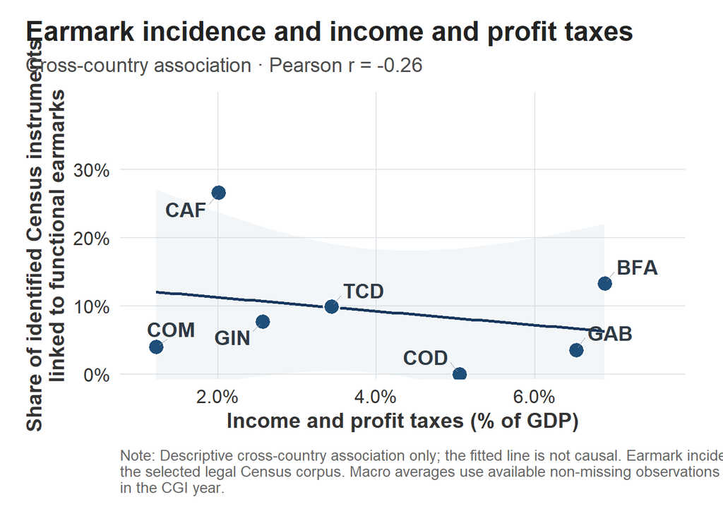

## Sales and production taxes

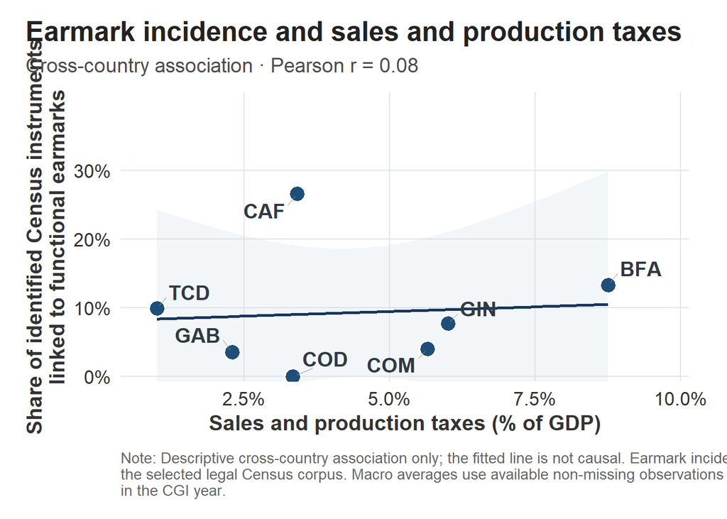

## Property taxes

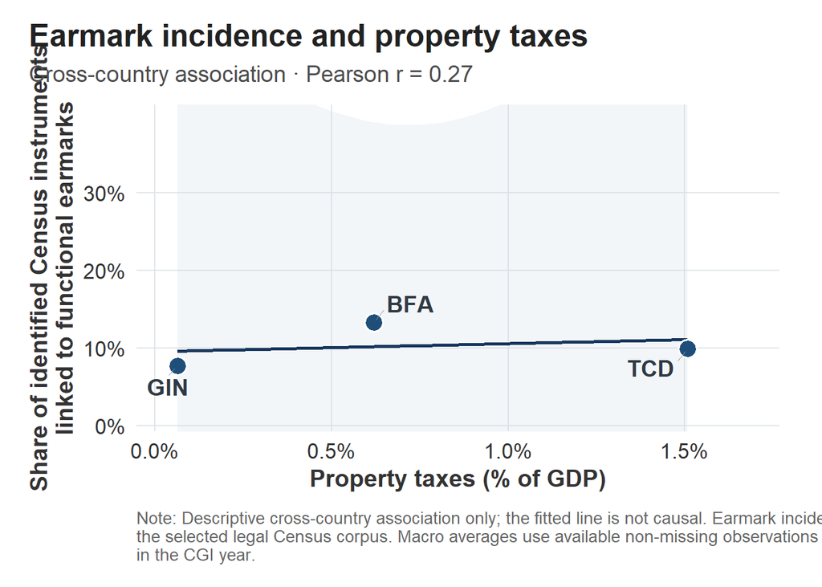

## Grants

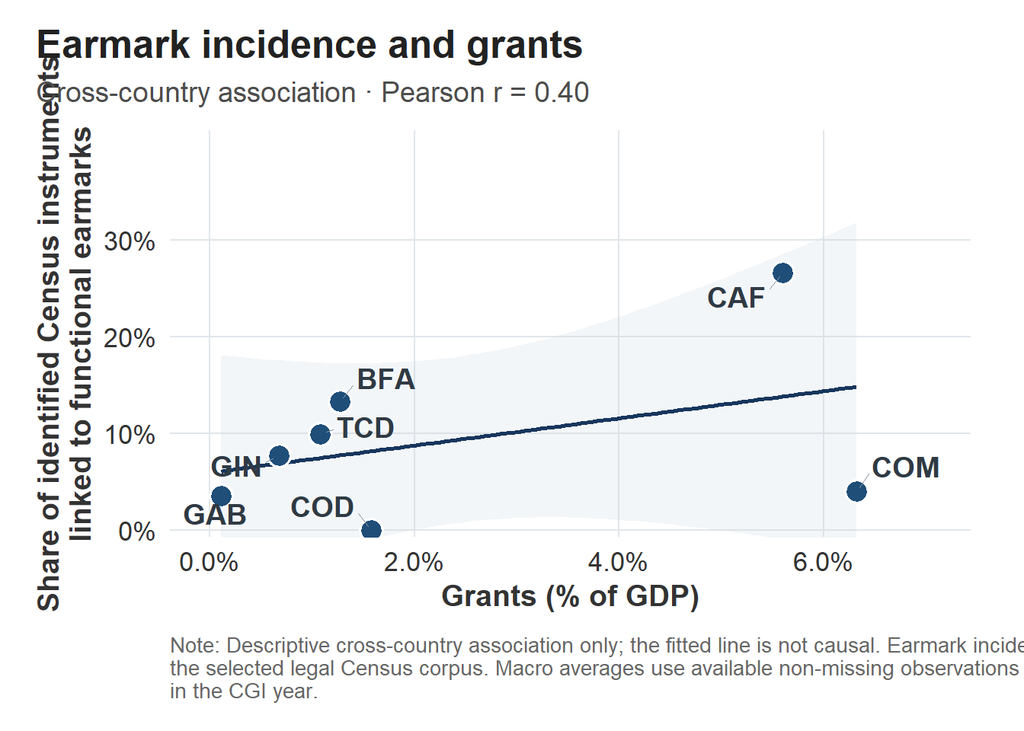

## Tax revenue

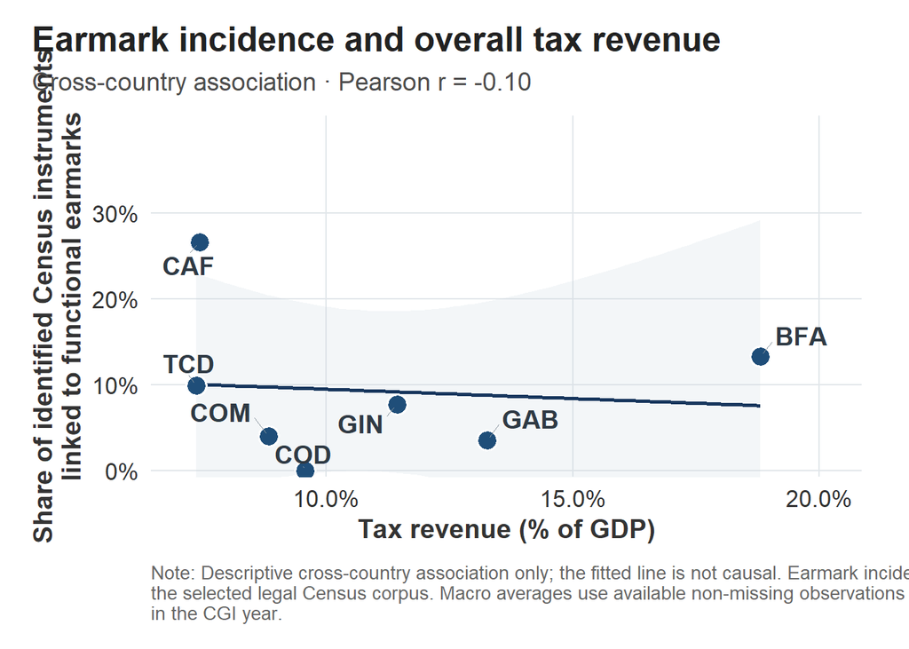

## Taxes on international trade

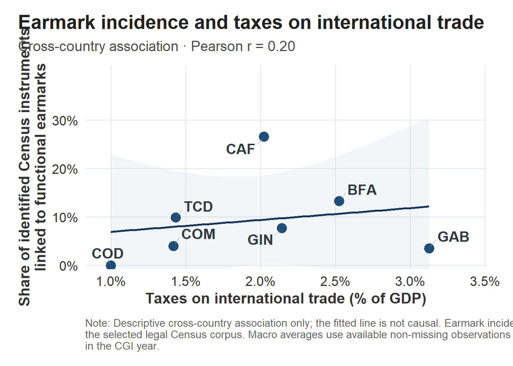

# 6. Save and verify the output bundle

```r
merged_output_path <- file.path(
  table_dir, "12_earmark_incidence_macro_3yr_averages.csv"
)
correlation_output_path <- file.path(
  table_dir, "12_earmark_incidence_macro_correlations.csv"
)

plot_csv_paths <- set_names(
  file.path(table_dir, paste0(indicator_meta$output_stem, ".csv")),
  indicator_meta$macro_indicator
)
plot_png_paths <- set_names(
  file.path(figure_dir, paste0(indicator_meta$output_stem, ".png")),
  indicator_meta$macro_indicator
)

expected_csv_data <- c(
  list(
    merged = macro_averages,
    correlations = correlation_summary
  ),
  plot_data_by_indicator
)

final_csv_paths <- c(
  merged = merged_output_path,
  correlations = correlation_output_path,
  plot_csv_paths
)
```

```r
stage_dir <- tempfile(pattern = "12_macro_fiscal_stage_")
dir.create(stage_dir, recursive = TRUE, showWarnings = FALSE)

stage_csv_paths <- set_names(
  file.path(stage_dir, basename(final_csv_paths)),
  names(final_csv_paths)
)
stage_png_paths <- set_names(
  file.path(stage_dir, basename(plot_png_paths)),
  names(plot_png_paths)
)

iwalk(expected_csv_data, function(data, name) {
  write_csv(data, stage_csv_paths[[name]], na = "")
})

iwalk(plot_objects, function(plot_object, indicator_code) {
  ggsave(
    filename = stage_png_paths[[indicator_code]],
    plot = plot_object,
    width = 11.5,
    height = 8.2,
    units = "in",
    dpi = 300,
    bg = "white"
  )
})

staged_csv_checks <- imap_dfr(
  expected_csv_data,
  function(expected, name) {
    saved <- read_csv(
      stage_csv_paths[[name]],
      show_col_types = FALSE,
      progress = FALSE
    )
    tibble(
      output = name,
      rows = nrow(saved),
      columns = ncol(saved),
      passed = same_table_values(saved, expected)
    )
  }
)

staged_png_checks <- imap_dfr(
  plot_objects,
  function(plot_object, indicator_code) {
    tibble(
      macro_indicator = indicator_code,
      png_bytes = file.info(stage_png_paths[[indicator_code]])$size,
      passed = file.exists(stage_png_paths[[indicator_code]]) &&
        file.info(stage_png_paths[[indicator_code]])$size > 10000
    )
  }
)

if (!all(staged_csv_checks$passed) || !all(staged_png_checks$passed)) {
  print(staged_csv_checks %>% filter(!passed))
  print(staged_png_checks %>% filter(!passed))
  stop("Staged CSV or PNG verification failed; final outputs were unchanged.")
}
```

```r
stage_paths <- c(
  set_names(unname(stage_csv_paths), paste0(names(stage_csv_paths), "_csv")),
  set_names(unname(stage_png_paths), paste0(names(stage_png_paths), "_png"))
)
final_paths <- c(
  set_names(unname(final_csv_paths), paste0(names(final_csv_paths), "_csv")),
  set_names(unname(plot_png_paths), paste0(names(plot_png_paths), "_png"))
)

commit_output_bundle <- function(stage_paths, final_paths) {
  existed_before <- set_names(file.exists(final_paths), names(final_paths))
  backup_dir <- tempfile(pattern = "12_macro_fiscal_backup_")
  dir.create(backup_dir, recursive = TRUE, showWarnings = FALSE)
  backup_paths <- set_names(
    file.path(backup_dir, basename(final_paths)),
    names(final_paths)
  )
  committed <- FALSE

  on.exit({
    if (!committed) {
      for (name in names(final_paths)) {
        if (existed_before[[name]] && file.exists(backup_paths[[name]])) {
          file.copy(
            backup_paths[[name]], final_paths[[name]], overwrite = TRUE
          )
        } else if (!existed_before[[name]] && file.exists(final_paths[[name]])) {
          file.remove(final_paths[[name]])
        }
      }
    }
    unlink(stage_dir, recursive = TRUE, force = TRUE)
    unlink(backup_dir, recursive = TRUE, force = TRUE)
  }, add = TRUE)

  for (name in names(final_paths)[existed_before]) {
    if (!file.copy(
      final_paths[[name]], backup_paths[[name]], overwrite = FALSE
    )) {
      stop("Could not create a rollback copy for ", name, ".")
    }
  }

  commit_ok <- vapply(
    names(final_paths),
    function(name) file.copy(
      stage_paths[[name]], final_paths[[name]], overwrite = TRUE
    ),
    logical(1)
  )
  if (!all(commit_ok)) {
    stop("Could not commit the complete output bundle.")
  }
  committed <- TRUE
  invisible(TRUE)
}

commit_output_bundle(stage_paths, final_paths)
```

```r
final_csv_checks <- imap_dfr(
  expected_csv_data,
  function(expected, name) {
    saved <- read_csv(
      final_csv_paths[[name]],
      show_col_types = FALSE,
      progress = FALSE
    )
    tibble(
      output = name,
      path = final_csv_paths[[name]],
      rows = nrow(saved),
      csv_matches = same_table_values(saved, expected)
    )
  }
)

final_png_checks <- imap_dfr(
  plot_objects,
  function(plot_object, indicator_code) {
    tibble(
      macro_indicator = indicator_code,
      path = plot_png_paths[[indicator_code]],
      png_bytes = file.info(plot_png_paths[[indicator_code]])$size,
      png_valid = file.exists(plot_png_paths[[indicator_code]]) &&
        file.info(plot_png_paths[[indicator_code]])$size > 10000
    )
  }
)

input_md5_after <- unname(tools::md5sum(input_paths))
input_preservation_check <- tibble(
  input = names(input_paths),
  md5_before = input_md5_before,
  md5_after = input_md5_after,
  unchanged = md5_before == md5_after
)

if (!all(final_csv_checks$csv_matches) ||
    !all(final_png_checks$png_valid) ||
    !all(input_preservation_check$unchanged)) {
  print(final_csv_checks %>% filter(!csv_matches))
  print(final_png_checks %>% filter(!png_valid))
  print(input_preservation_check %>% filter(!unchanged))
  stop("Final output or input-preservation checks failed.")
}
```

```r
display_table(input_preservation_check)
```

| input | md5_before | md5_after | unchanged |
| --- | --- | --- | --- |
| incidence | 9a5a1b252672b656f8a2947f6db0b82f | 9a5a1b252672b656f8a2947f6db0b82f | TRUE |
| corpus_coverage | e2aa88b1af8f5852b995905d570ceb11 | e2aa88b1af8f5852b995905d570ceb11 | TRUE |
| imf_world | 05a67fbe13e1e063c6891a79c973787e | 05a67fbe13e1e063c6891a79c973787e | TRUE |

```r
display_table(final_csv_checks)
```

| output | path | rows | csv_matches |
| --- | --- | --- | --- |
| merged | C:/Users/alexa/Documents/earmarking-ssa/analysis/tables/partial_exclusive/12_earmark_incidence_macro_3yr_averages.csv | 96 | TRUE |
| correlations | C:/Users/alexa/Documents/earmarking-ssa/analysis/tables/partial_exclusive/12_earmark_incidence_macro_correlations.csv | 6 | TRUE |
| TaxInc | C:/Users/alexa/Documents/earmarking-ssa/analysis/tables/partial_exclusive/12_earmark_incidence_income_profit_tax.csv | 7 | TRUE |
| TaxSal | C:/Users/alexa/Documents/earmarking-ssa/analysis/tables/partial_exclusive/12_earmark_incidence_sales_production_tax.csv | 7 | TRUE |
| TaxPro | C:/Users/alexa/Documents/earmarking-ssa/analysis/tables/partial_exclusive/12_earmark_incidence_property_tax.csv | 3 | TRUE |
| Grants | C:/Users/alexa/Documents/earmarking-ssa/analysis/tables/partial_exclusive/12_earmark_incidence_grants.csv | 7 | TRUE |
| TaxRev | C:/Users/alexa/Documents/earmarking-ssa/analysis/tables/partial_exclusive/12_earmark_incidence_tax_revenue.csv | 7 | TRUE |
| TaxTra | C:/Users/alexa/Documents/earmarking-ssa/analysis/tables/partial_exclusive/12_earmark_incidence_international_trade_tax.csv | 7 | TRUE |

```r
display_table(final_png_checks)
```

| macro_indicator | path | png_bytes | png_valid |
| --- | --- | --- | --- |
| TaxInc | C:/Users/alexa/Documents/earmarking-ssa/analysis/figures/partial_exclusive/12_earmark_incidence_income_profit_tax.png | 250273 | TRUE |
| TaxSal | C:/Users/alexa/Documents/earmarking-ssa/analysis/figures/partial_exclusive/12_earmark_incidence_sales_production_tax.png | 241212 | TRUE |
| TaxPro | C:/Users/alexa/Documents/earmarking-ssa/analysis/figures/partial_exclusive/12_earmark_incidence_property_tax.png | 200372 | TRUE |
| Grants | C:/Users/alexa/Documents/earmarking-ssa/analysis/figures/partial_exclusive/12_earmark_incidence_grants.png | 240276 | TRUE |
| TaxRev | C:/Users/alexa/Documents/earmarking-ssa/analysis/figures/partial_exclusive/12_earmark_incidence_tax_revenue.png | 233171 | TRUE |
| TaxTra | C:/Users/alexa/Documents/earmarking-ssa/analysis/figures/partial_exclusive/12_earmark_incidence_international_trade_tax.png | 242399 | TRUE |

# 7. Completion summary

```r
zero_year_rows <- macro_averages %>% filter(n_years_used == 0L)
short_nonzero_rows <- macro_averages %>%
  filter(n_years_used > 0L, n_years_used < 3L)

cat(
  "- Francophone countries retained: ",
  n_distinct(francophone_incidence$country),
  " (", paste(francophone_incidence$country, collapse = ", "), ").\n",
  "- Countries excluded by instruction: ",
  paste(excluded_countries, collapse = ", "), ".\n",
  "- IMF data end in ", imf_year_coverage$last_year, ".\n",
  "- Country-variable averages with zero usable years: ",
  nrow(zero_year_rows), ".\n",
  "- Country-variable averages based on one or two years: ",
  nrow(short_nonzero_rows), ".\n",
  "- Countries used by indicator: ",
  paste0(
    correlation_summary$macro_indicator,
    " = ", correlation_summary$n_countries,
    collapse = "; "
  ),
  ".\n",
  "- Unmatched retained countries in IMF data: ",
  nrow(unmatched_incidence_to_imf), ".\n",
  "- No causal interpretation is attached to the fitted lines or ",
  "correlations.\n",
  sep = ""
)
```

- Francophone countries retained: 16 (BEN, BFA, CAF, CIV, CMR, COD, COG, COM, GAB, GIN, MDG, MLI, NER, SEN, TCD, TGO).
- Countries excluded by instruction: GHA, NGA, ZAF.
- IMF data end in 2024.
- Country-variable averages with zero usable years: 58.
- Country-variable averages based on one or two years: 23.
- Countries used by indicator: TaxInc = 7; TaxSal = 7; TaxPro = 3; Grants = 7; TaxRev = 7; TaxTra = 7.
- Unmatched retained countries in IMF data: 0.
- No causal interpretation is attached to the fitted lines or correlations.